# Polish fresh chicken imports into the UK

# Calculate variance between two halfs of cost/kg over two time periods

```r
(var_2009_2012 <- var(model_data_group %>% filter(smk_period_reference <                           "2012-06-01") %>% select(cost_per_kg)))
```

```
            cost_per_kg
cost_per_kg  0.03493561
```

```r
(var_2012_2017 <- var(model_data_group %>% filter(smk_period_reference >                           "2012-06-01") %>% select(cost_per_kg)))
```

```
            cost_per_kg
cost_per_kg   0.7198691
```

# What does the nett mass of Polish fresh chicken imported into the UK look like over time?

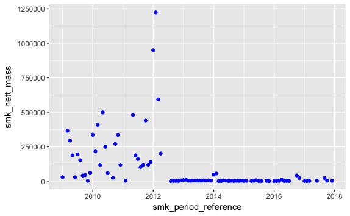

```r
ggplot(model_data_group, aes(smk_period_reference, smk_nett_mass)) +
        geom_point(colour = "blue")
```

- Imports of chicken very irregular and larger nett mass from 2009 - midway 2012. * Midway 2012 - 2017 much more regular and significantly less imported

# What does the nett mass of Polish fresh chicken imported into the UK look like between mid 2012 - current?

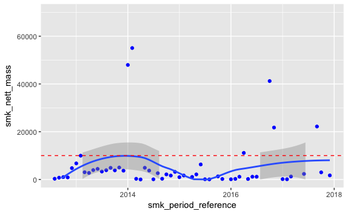

```r
ggplot(model_data_group %>% filter(smk_period_reference > "2012-06-01"),                 aes(smk_period_reference, smk_nett_mass)) +
        geom_point(colour = "blue") +
        ylim(0,70000) +
        geom_smooth() +
        geom_hline(yintercept=10000, linetype="dashed", color = "red")
```

- Some outliers still observed

# Did the number of consignments also increase during the spikes?

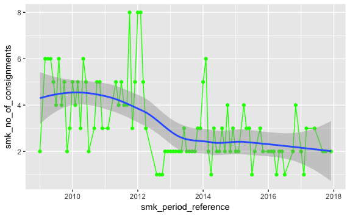

```r
ggplot(model_data_group, aes(smk_period_reference, smk_no_of_consignments)) +
        geom_line(colour = "green") +
        geom_point(colour = "green") +
        geom_smooth()
```

- Opposite relationship observed compared to cost/kg trend over time

# Conclusions and questions

- Patterns of fresh chicken imports from Poland have changed dramatically after midway 2012
- Where did all the extra chciken come from - especially between 2009 and midway 2012?
- Still some anomalies of fresh chicken imports in recent time